# Trp53cor1 KO vs WT (Adult)

# Design Overview

This file shows the wt-v-ko comparison for Trp53cor1.

Cuff overview:

```
## CuffSet instance with:
##   2 samples
##   26754 genes
##   77524 isoforms
##   0 TSS
##   23066 CDS
##   0 promoters
##   0 splicing
##   19954 relCDS
```

# QC

## Dispersion

Dispersion plot for genes in cuff: (Overdispersion can lead to innacurate quants)

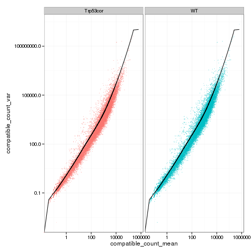

## Cross-replicate variability (fpkmSCVplot)

Differences in CV 2 can result in lower numbers of differentially expressed genes due to a higher degree of variability between replicate fpkm estimates.

Genes:

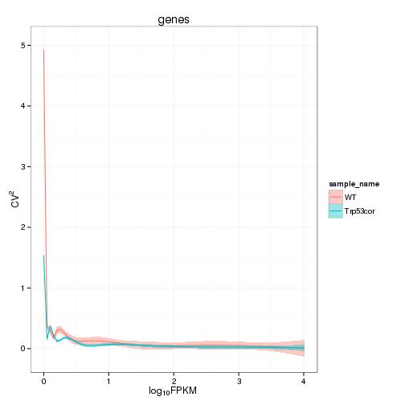

Isoforms:

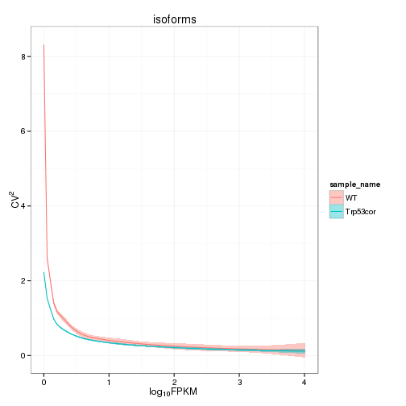

[output not shown]

[output not shown]

## Scatterplot matrix

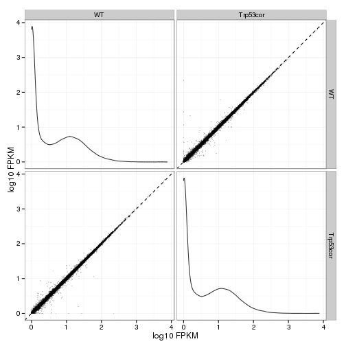

## Distributions

### Boxplots

Boxplot (genes)

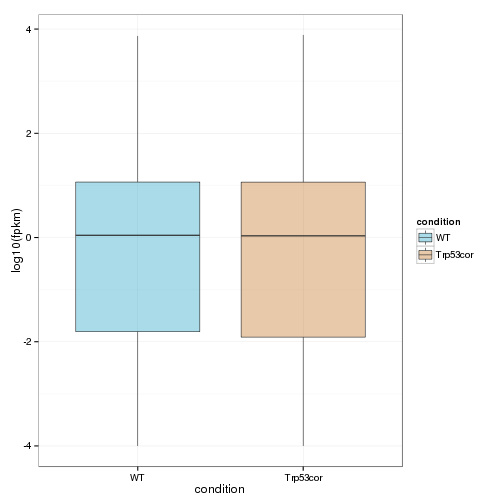

Boxplot (genes, replicates)

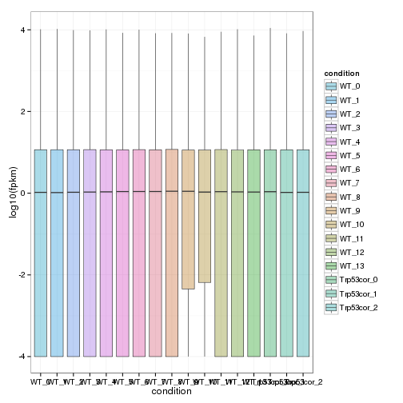

Boxplot (isoforms)

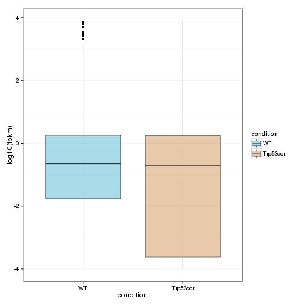

Boxplot (isoforms, replicates)

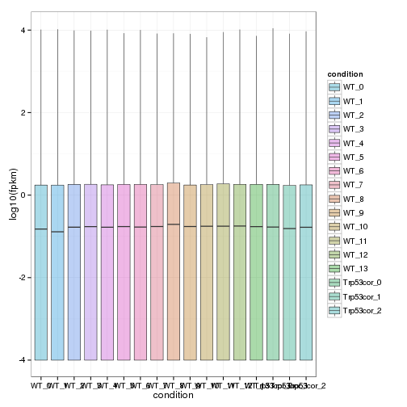

### Density

Density (genes)

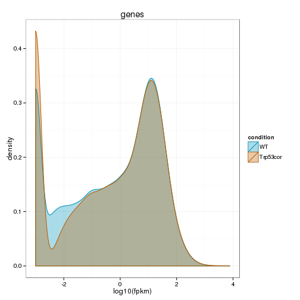

Density (genes, replicates)

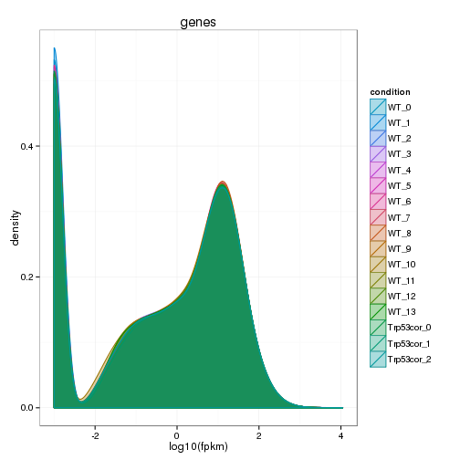

## Clustering

### Replicate Clusters

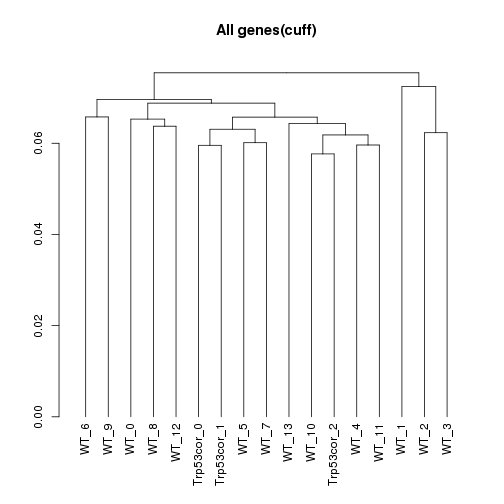

### PCA (genes)

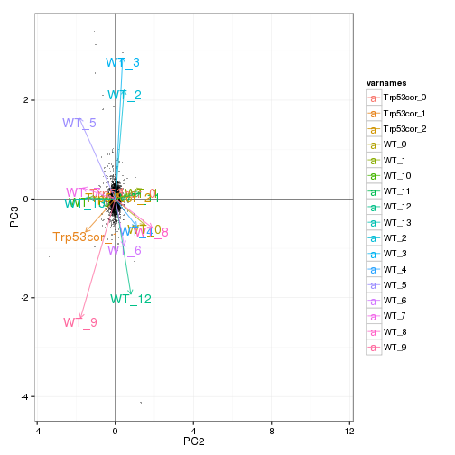

### MDS (genes)

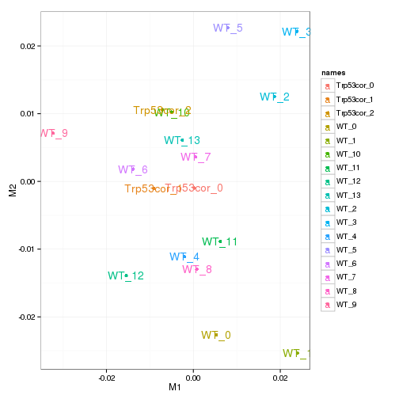

# KO assessment

## Endogenous lncRNA expression

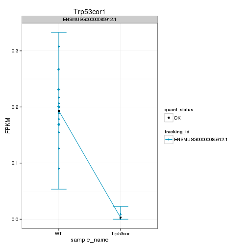

Endogenous expression of Trp53cor1 isoforms:

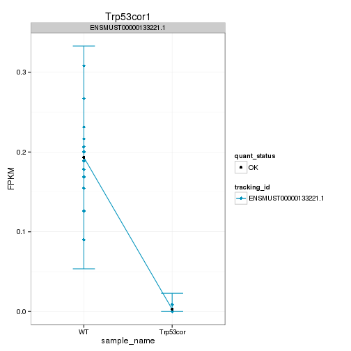

Barplot of gene expression:

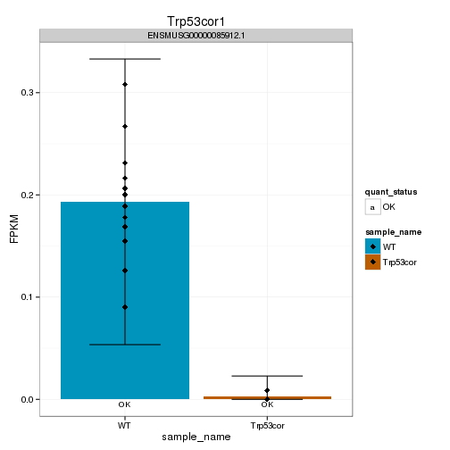

Barplot of isoform expression:

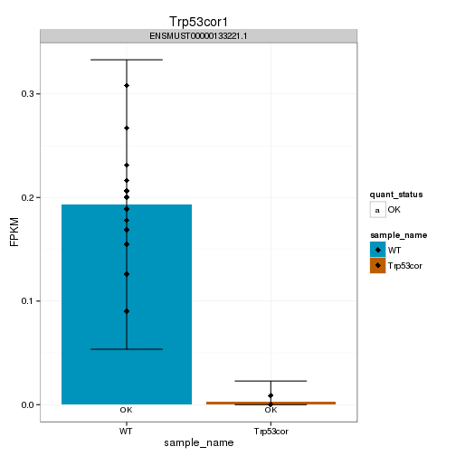

## LacZ expression

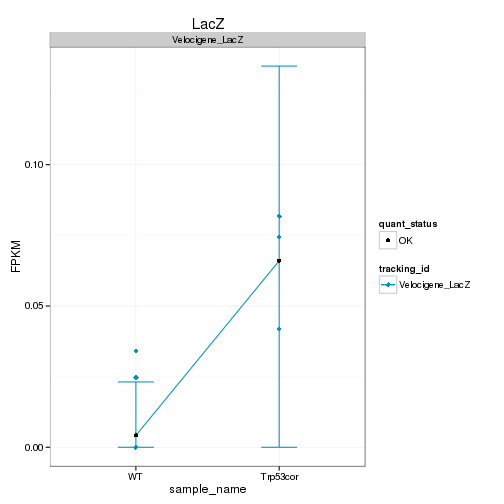

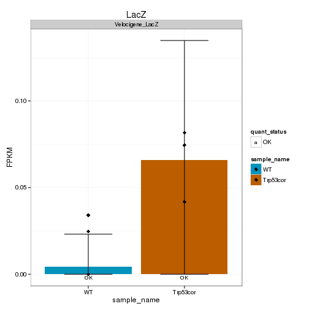

## Digital Genotyping (LacZ vs Endogenous lncRNA and Sex)

Expression plot (endogenous linc, lacZ, Y-expressed gene):

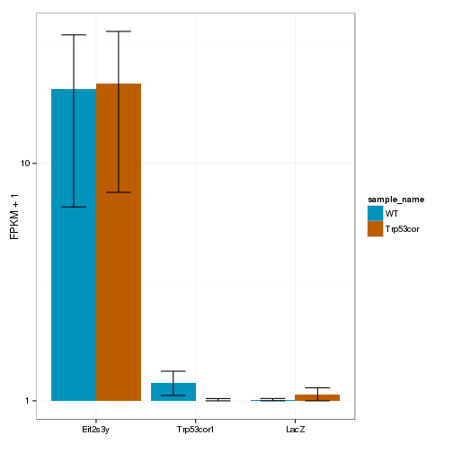

Expression heatmap:

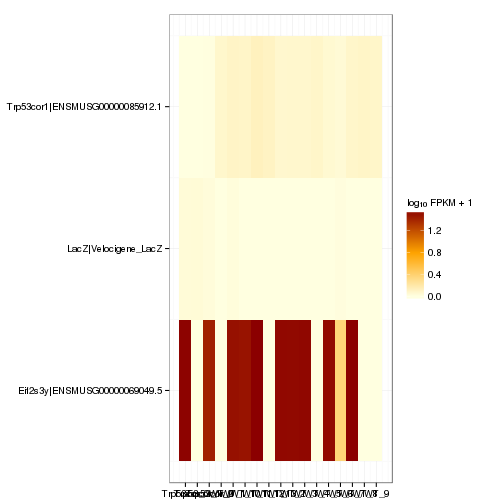

### Track visualization

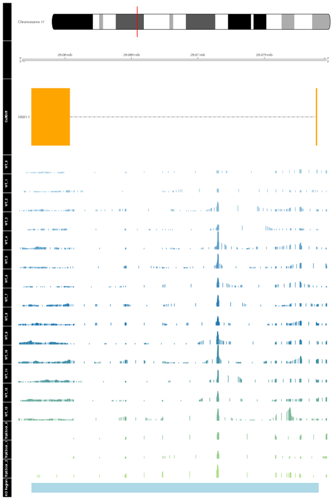

# Differential Analysis

## Differential Genes

There are 68 significantly differentially expressed genes. They are:

|  | geneAnnot$gene_short_name |
| --- | --- |
| 1 | Gabra2 |
| 2 | Arrdc2 |
| 3 | Nes |
| 4 | Epha2 |
| 5 | Khsrp |
| 6 | Odc1 |
| 7 | Tjap1 |
| 8 | Etnppl |
| 9 | Fabp7 |
| 10 | Sgk1 |
| 11 | Adi1 |
| 12 | Serpina3n |
| 13 | Kcnv1 |
| 14 | Cdkn1a |
| 15 | Park2 |
| 16 | Flywch2 |
| 17 | Mut |
| 18 | Enpp4 |
| 19 | Ppil1 |
| 20 | Cpne5 |
| 21 | Pi16 |
| 22 | Glo1 |
| 23 | Prss41 |
| 24 | Atp6v0c |
| 25 | Spsb3 |
| 26 | Adamts10 |
| 27 | Rps24 |
| 28 | Adamts9 |
| 29 | Gkn3 |
| 30 | A2m |
| 31 | Hddc3 |
| 32 | Plat |
| 33 | Tlr13 |
| 34 | Arhgap27 |
| 35 | Rnps1 |
| 36 | Lars2 |
| 37 | 3110052M02Rik |
| 38 | Decr2 |
| 39 | Cramp1l |
| 40 | Gm129 |
| 41 | Akap12 |
| 42 | Itpkb |
| 43 | Lyplal1 |
| 44 | Fmo2 |
| 45 | Maff |
| 46 | Pgp |
| 47 | Gm9493 |
| 48 | Zfp758 |
| 49 | Acp1 |
| 50 | Hmga1 |
| 51 | Tmem252 |
| 52 | Pla2g4e |
| 53 | Tagap1 |
| 54 | Arntl |
| 55 | Per2 |
| 56 | H2-T22 |
| 57 | Ide |
| 58 | Gm10123 |
| 59 | H2-T23 |
| 60 | Zfp760 |
| 61 | Gm7292 |
| 62 | H2-Bl |
| 63 | 9030025P20Rik |
| 64 | Mog |
| 65 | Apold1 |
| 66 | AA465934 |
| 67 | Gm9825 |
| 68 | Tmem181b-ps |

### Matrix of gene significant differences between conditions

(skip for Brainmap wt-v-ko comparisons)

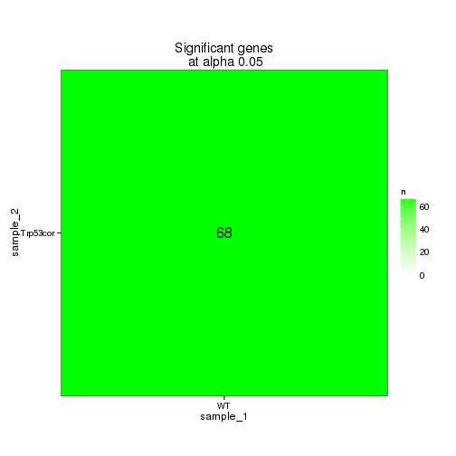

### Significant gene expression differences between conditions

Expression plot (genes):

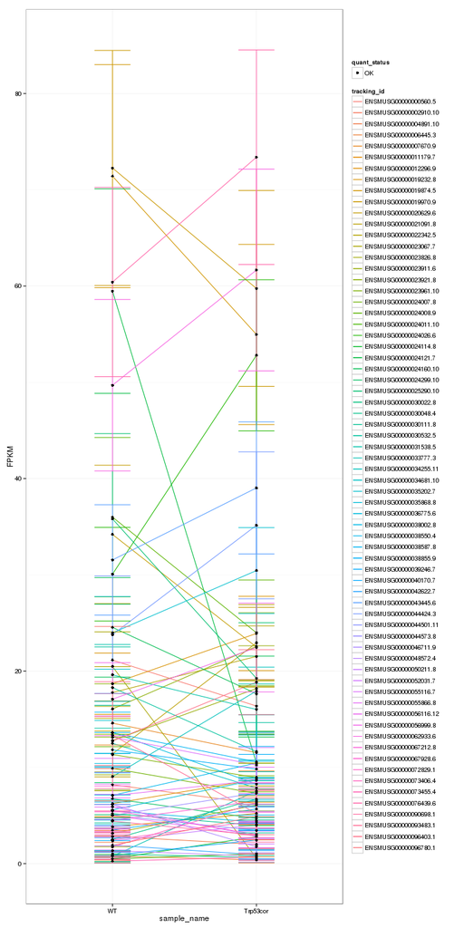

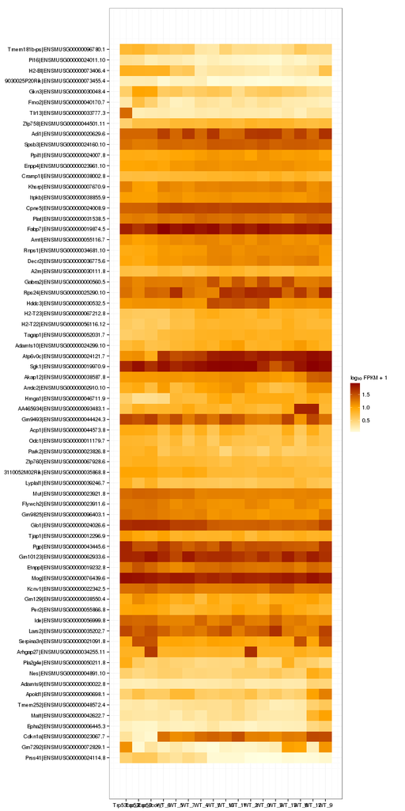

Significant genes with expression >50fpkm (any condition):

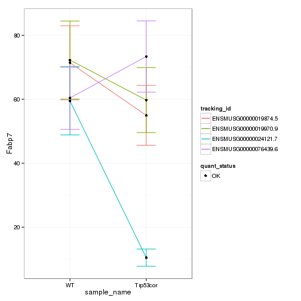

[output not shown]

[output not shown]

FoldChange Heatmap

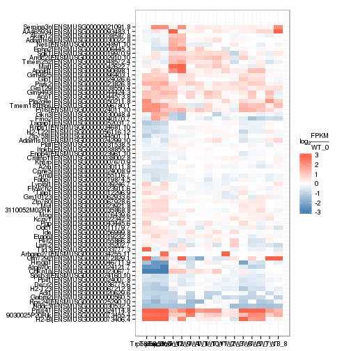

## Differential Splicing

### Differential Isoforms between conditions

Per isoform difference between conditions:

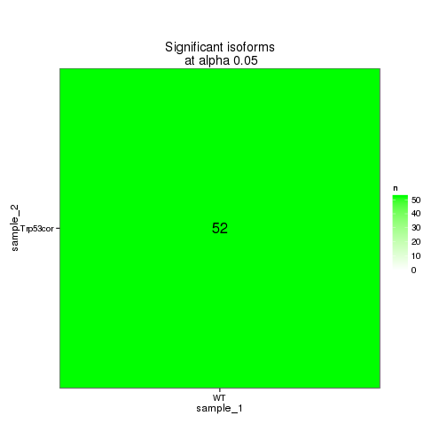

These isoforms are:

|  | isoAnnot$gene_short_name |
| --- | --- |
| 1 | Gabra2 |
| 2 | Rec8 |
| 3 | Arrdc2 |
| 4 | Klf4 |
| 5 | Nes |
| 6 | Prlr |
| 7 | Epha2 |
| 8 | Khsrp |
| 9 | Etnppl |
| 10 | Fabp7 |
| 11 | Serpina3n |
| 12 | Kcnv1 |
| 13 | Tfrc |
| 14 | Cdkn1a |
| 15 | Hcfc1r1 |
| 16 | Flywch2 |
| 17 | Mut |
| 18 | Ppil1 |
| 19 | Cpne5 |
| 20 | Glo1 |
| 21 | Atp6v0c |
| 22 | Adamts10 |
| 23 | Rps24 |
| 24 | Gng13 |
| 25 | Gkn3 |
| 26 | A2m |
| 27 | Hddc3 |
| 28 | Rnps1 |
| 29 | Lars2 |
| 30 | 3110052M02Rik |
| 31 | Decr2 |
| 32 | Cramp1l |
| 33 | Ano2 |
| 34 | Akap12 |
| 35 | Lyplal1 |
| 36 | Fmo2 |
| 37 | Bcor |
| 38 | Gm9493 |
| 39 | Pla2g4e |
| 40 | Tagap1 |
| 41 | Arntl |
| 42 | Ide |
| 43 | Zfp945 |
| 44 | Gm10123 |
| 45 | Zfp760 |
| 46 | Fndc1 |
| 47 | H2-Bl |
| 48 | 9030025P20Rik |
| 49 | Mog |
| 50 | Apold1 |
| 51 | Gm9825 |
| 52 | Tmem181b-ps |

Gene-level DE isoform heatmap

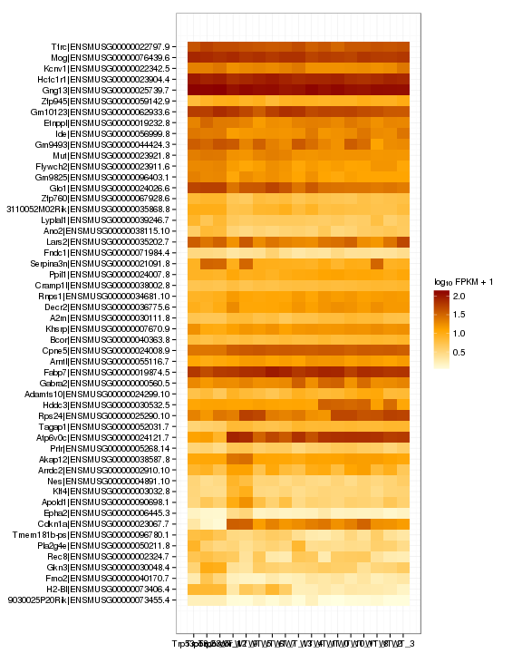

Isoform foldchange heatmap by isoform:

[figure not shown]